# Introduction to Point Pattern Analysis

Caso Homogeneo

```r
# modelo homogeneo
ajus.CSR.1<-ppm(sim.CSR~1)
ajus.CSR.1
```

```
Stationary Poisson process
Intensity: 91
```

|  | Estimate | S.E. | CI95.lo | CI95.hi | Ztest | Zval |
| --- | --- | --- | --- | --- | --- | --- |
| log(lambda) | 4.51086 | 0.1048285 | 4.305399 | 4.71632 | *** | 43.03086 |

```r
# modelo cinhomogeneo on tendencia espacial lineal
ajus.CSR.2<-ppm(sim.CSR~x+y)
ajus.CSR.2
```

```
Nonstationary Poisson process

Log intensity:  ~x + y

Fitted trend coefficients:
(Intercept)           x           y
 4.52381507  0.06116668 -0.08803713
```

|  | Estimate | S.E. | CI95.lo | CI95.hi | Ztest | Zval |
| --- | --- | --- | --- | --- | --- | --- |
| (Intercept) | 4.52381507 | 0.2769819 | 3.9809404 | 5.0666897 | *** | 16.3325273 |
| x | 0.06116668 | 0.3633154 | -0.6509185 | 0.7732518 |  | 0.1683569 |
| y | -0.08803713 | 0.3633713 | -0.8002318 | 0.6241576 |  | -0.2422787 |

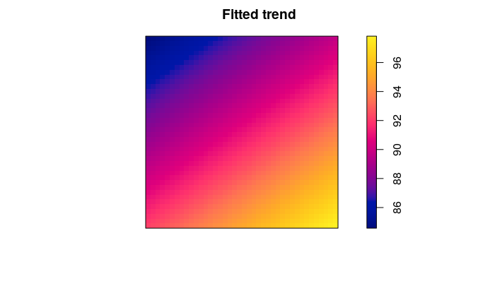

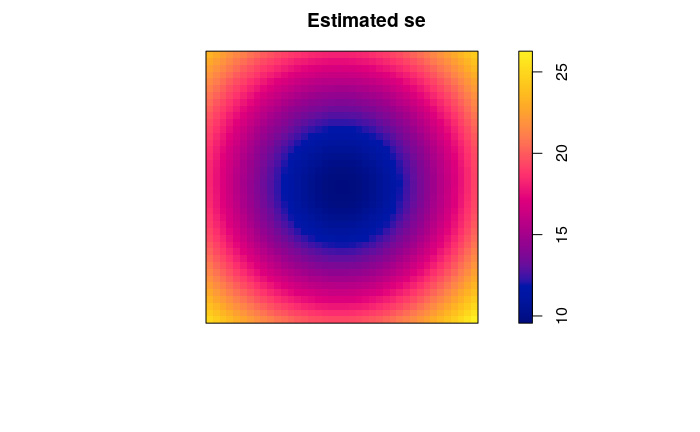

```r
plot(ajus.CSR.2,pause=FALSE,superimpose = FALSE)
```

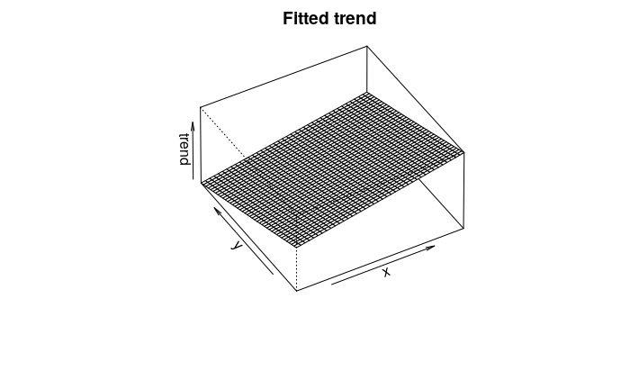

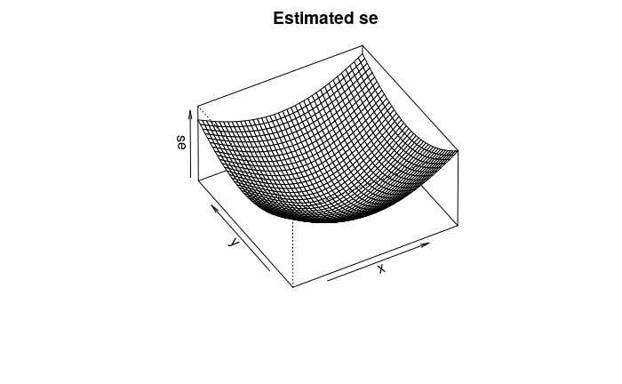

```r
plot(ajus.CSR.2,pause=FALSE,how="persp", theta=-30,phi=40,d=4)
```

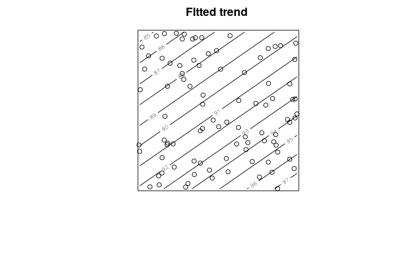

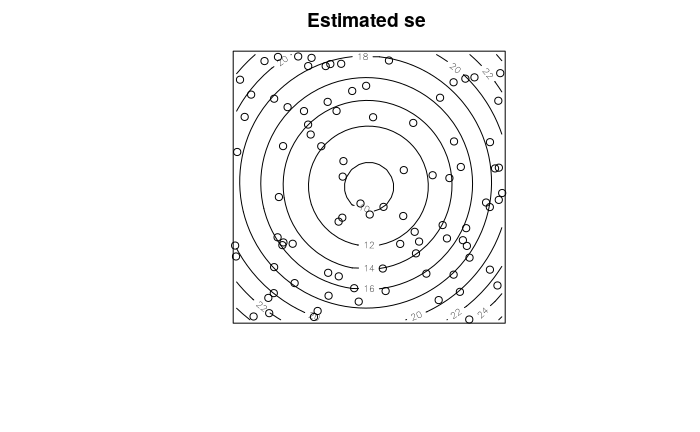

```r
plot(ajus.CSR.2,pause=FALSE,how="contour", theta=-30,phi=40,d=4)
```

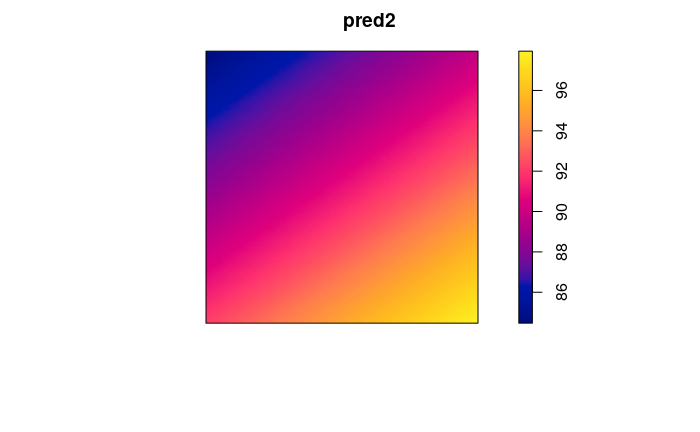

```r
pred2<-predict(ajus.CSR.2)
plot(pred2)
```

Caso InHomogeneo

```r
# modelo homogeneo
ajus.INH.1<-ppm(sim.INHa~1)
ajus.INH.1
```

```
Stationary Poisson process
Intensity: 126
```

|  | Estimate | S.E. | CI95.lo | CI95.hi | Ztest | Zval |
| --- | --- | --- | --- | --- | --- | --- |
| log(lambda) | 4.836282 | 0.08908708 | 4.661674 | 5.010889 | *** | 54.28713 |

```r
# modelo cinhomogeneo on tendencia espacial lineal
ajus.INH.2<-ppm(sim.INHa~x+y)
ajus.INH.2
```

```
Nonstationary Poisson process

Log intensity:  ~x + y

Fitted trend coefficients:
(Intercept)           x           y
 4.68074523 -0.08171004  0.38018558
```

|  | Estimate | S.E. | CI95.lo | CI95.hi | Ztest | Zval |
| --- | --- | --- | --- | --- | --- | --- |
| (Intercept) | 4.68074523 | 0.2413345 | 4.2077383 | 5.1537521 | *** | 19.3952605 |
| x | -0.08171004 | 0.3087647 | -0.6868778 | 0.5234577 |  | -0.2646353 |
| y | 0.38018558 | 0.3097641 | -0.2269410 | 0.9873121 |  | 1.2273389 |

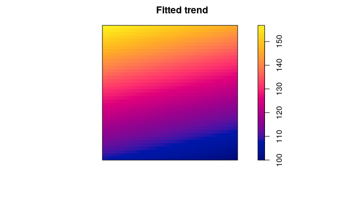

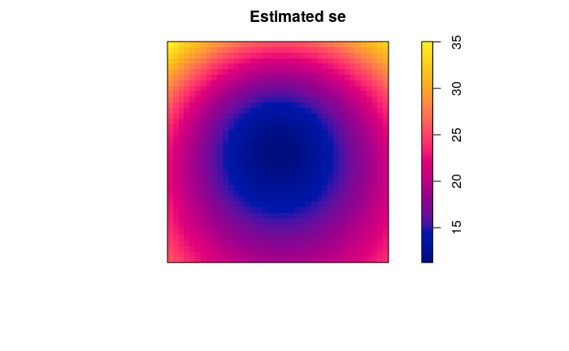

```r
plot(ajus.INH.2,pause=FALSE,superimpose = FALSE)
```

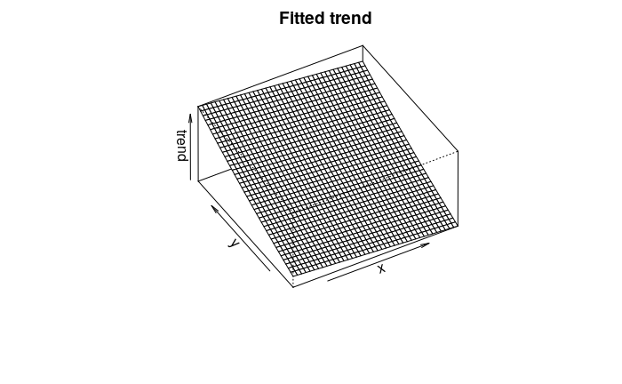

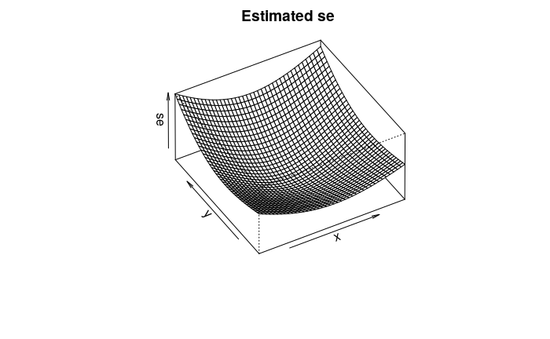

```r
plot(ajus.INH.2,pause=FALSE,how="persp", theta=-30,phi=40,d=4)
```

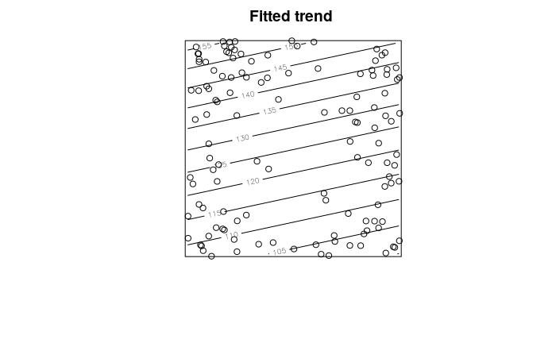

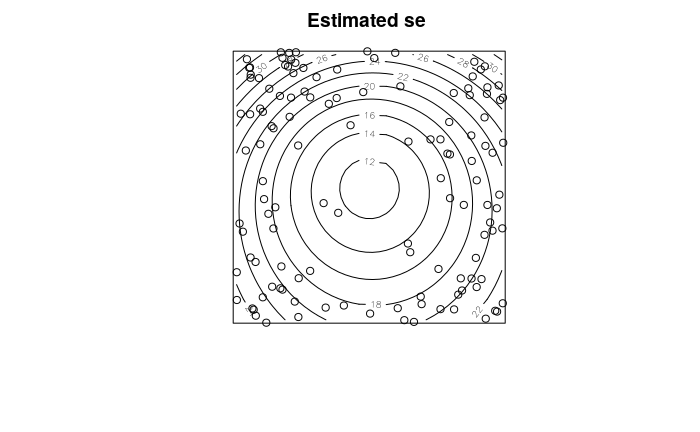

```r
plot(ajus.INH.2,pause=FALSE,how="contour", theta=-30,phi=40,d=4)
```

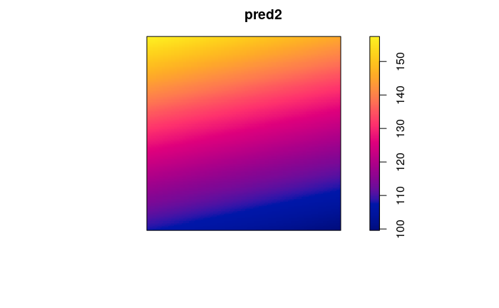

```r
pred2<-predict(ajus.INH.2)
plot(pred2)
```

```r
# modelo cinhomogeneo on tendencia espacial NO lineal
require(splines)
#ajus.INH.3<-ppm(sim.INHa~bs(x,df=2)+bs(y,df=2),Poisson())

ajus.INH.3<-ppm(sim.INHa~poly(x,2)+poly(y,2),Poisson())

ajus.INH.3
```

```
Nonstationary Poisson process

Log intensity:  ~poly(x, 2) + poly(y, 2)

Fitted trend coefficients:
(Intercept) poly(x, 2)1 poly(x, 2)2 poly(y, 2)1 poly(y, 2)2
  4.6815325  -0.3972158  15.8736932   2.8181625  14.0666392
```

|  | Estimate | S.E. | CI95.lo | CI95.hi | Ztest | Zval |
| --- | --- | --- | --- | --- | --- | --- |
| (Intercept) | 4.6815325 | 0.1019326 | 4.481748 | 4.881317 | *** | 45.9277186 |
| poly(x, 2)1 | -0.3972158 | 2.5786078 | -5.451194 | 4.656763 |  | -0.1540427 |
| poly(x, 2)2 | 15.8736932 | 2.8529773 | 10.281960 | 21.465426 | *** | 5.5639046 |
| poly(y, 2)1 | 2.8181625 | 2.6344315 | -2.345228 | 7.981553 |  | 1.0697422 |
| poly(y, 2)2 | 14.0666392 | 2.8831711 | 8.415728 | 19.717551 | *** | 4.8788777 |

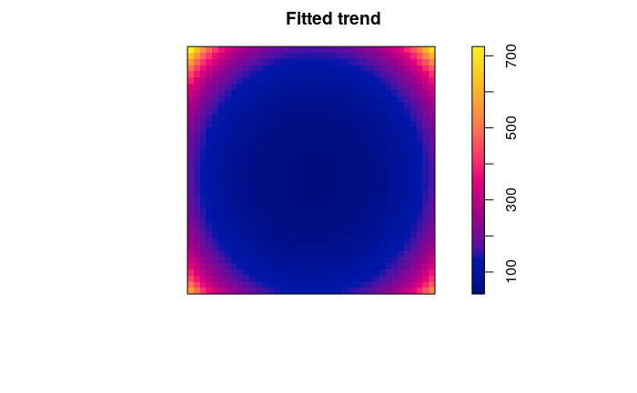

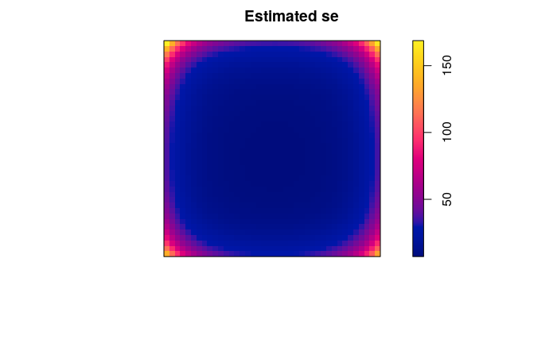

```r
plot(ajus.INH.3,pause=FALSE,superimpose = FALSE)
```

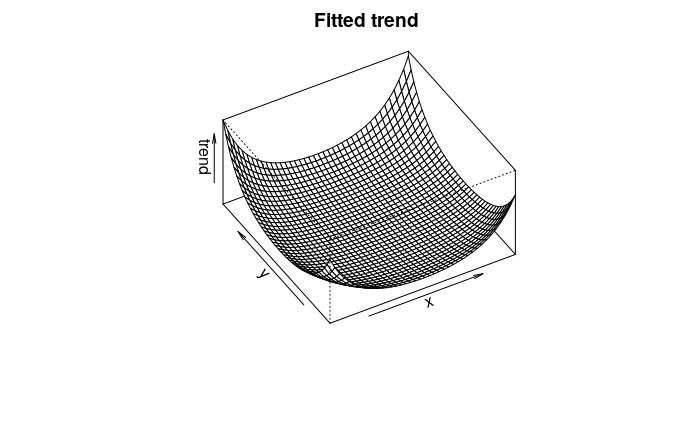

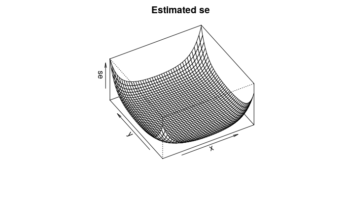

```r
plot(ajus.INH.3,pause=FALSE,how="persp", theta=-30,phi=40,d=4)
```

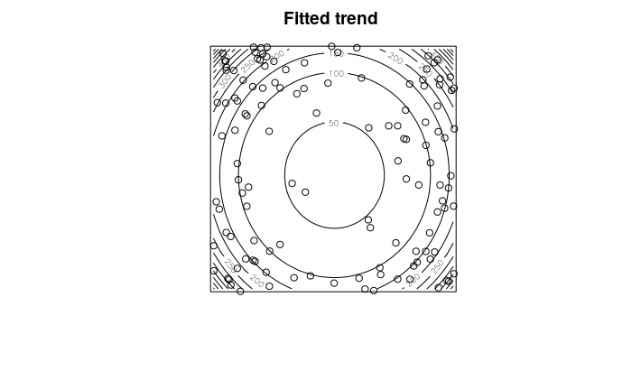

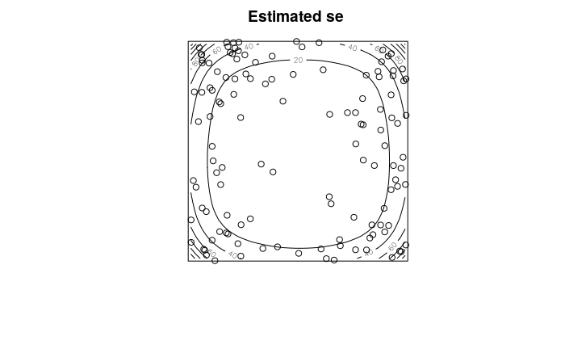

```r
plot(ajus.INH.3,pause=FALSE,how="contour", theta=-30,phi=40,d=4)
```

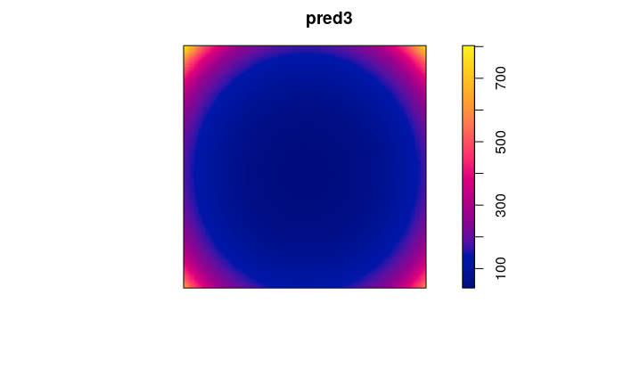

```r
pred3<-predict(ajus.INH.3)
plot(pred3)
```

Como funciona KDE

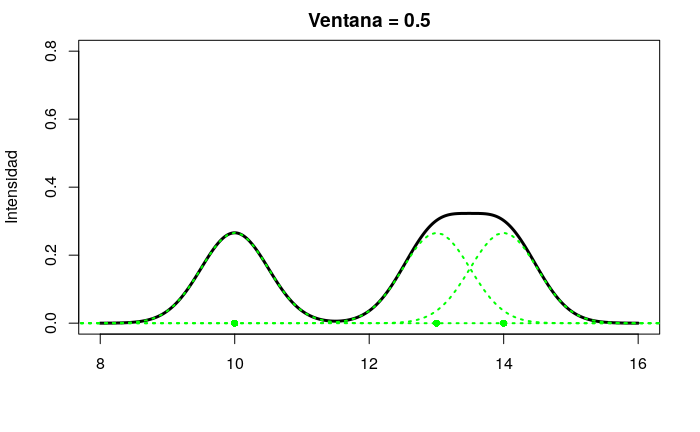

```r
library(manipulate)
x<-c(10,13,14)

GrafKDE<-function(h)
{
plot(density(x,bw=h,from=8,to=16),main=paste("Ventana =",h),ylab="Intensidad",ylim=c(0,0.8),lwd=3,xlab="")
points(x,c(0,0,0),pch=16,col="green")
n1<-function(x){dnorm(x,10,h)/3}
n2<-function(x){dnorm(x,13,h)/3}
n3<-function(x){dnorm(x,14,h)/3}
curve(n1, 7, 17, lwd=2, axes = FALSE, xlab = "", ylab = "",add=T,col="green",lty=3)
curve(n2, 7, 17, lwd=2, axes = FALSE, xlab = "", ylab = "",add=T,col="green",lty=3)
curve(n3, 7, 17, lwd=2, axes = FALSE, xlab = "", ylab = "",add=T,col="green",lty=3)
}
GrafKDE(0.5)
```

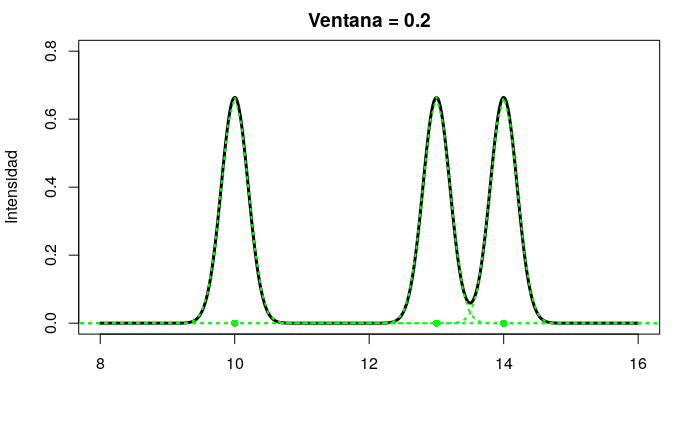

```r
manipulate(GrafKDE(h=h),h=slider(0.2,2,step=0.1))
```

Aplicacion de KDE a Poisson Homogeneo

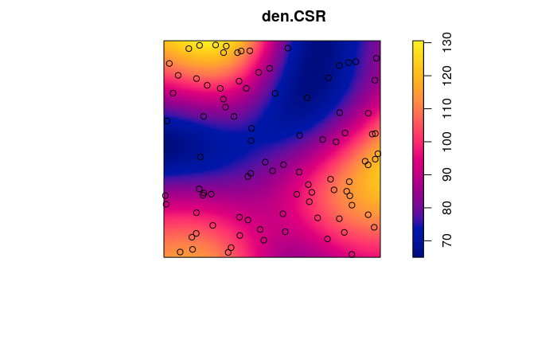

```r
require(splancs)
# eleccion de ventana por diggle
mserw <- bw.diggle(sim.CSR)
bw <- as.numeric(mserw)*3
#
den.CSR<-density(sim.CSR,bw)
plot(den.CSR)
points(sim.CSR)
```

Aplicacion de KDE a Poisson InHomogeneo

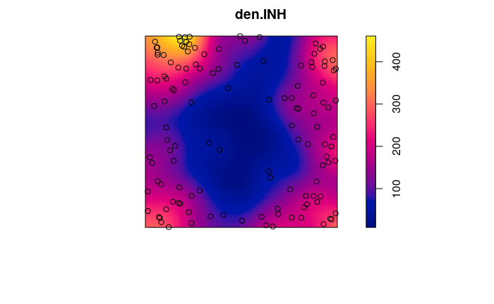

```r
require(splancs)
# eleccion de ventana por diggle
mserw <- bw.diggle(sim.INHa)
bw <- as.numeric(mserw)*3
#
den.INH<-density(sim.INHa,bw)
plot(den.INH)
points(sim.INHa)
```

Elegiendo la ventana optima para Poisson Inhomogeneo

```r
require(spatstat.utils)
#datos<-sim.CSR
datos<-sim.INHa
poligono<-matrix(c(0,0,0,1,1,0,1,1,0,0),4,2,byrow = T)
```

```
data length [10] is not a sub-multiple or multiple of the number of rows [4]
```

```r
Mse2d <- mse2d(as.points(datos), poligono, nsmse=50, range=1)
#png("/home/andresfaral/Dropbox/Estadistica Espacial/KDE INH CV")
plot(Mse2d$h,Mse2d$mse, type="l",xlab="Ventana (h)", ylab="Error Estimado")
arrows(0.15,9,0.15,-1.5,lty=1,col="green",lwd=3)
```

[output not shown]

```r
#dev.off()
bw<-min(Mse2d$h)
bw<-0.03
den.INH<-density(datos,bw)
png("/home/andresfaral/Dropbox/Estadistica Espacial/KDE INH chico")
plot(den.INH)
```

[figure not shown]

```r
points(datos)
dev.off()
```

Elegiendo la ventana optima para Thomas

```r
datos<-sim.THO
poligono<-matrix(c(0,0,0,1,1,0,1,1,0,0),4,2,byrow = T)
```

```
data length [10] is not a sub-multiple or multiple of the number of rows [4]
```

```r
Mse2d <- mse2d(as.points(datos), poligono, nsmse=50, range=1)
bw<-Mse2d$h[which.min(Mse2d$mse)]
png("/home/andresfaral/Dropbox/Estadistica Espacial/KDE THO CV")
plot(Mse2d$h,Mse2d$mse, type="l",xlab="Ventana (h)", ylab="Error Estimado")
arrows(bw,-1,bw,-4.5,lty=1,col="green",lwd=2)
dev.off()
```

```r
den.THO<-density(datos,bw)
png("/home/andresfaral/Dropbox/Estadistica Espacial/KDE THO")
```

```r
plot(den.THO)
points(datos)
dev.off()
```

Procesos Marcados

```r
library(gstat)
library(lattice)
library(sp)
data(meuse)
class(meuse)
```

```
[1] "data.frame"
```

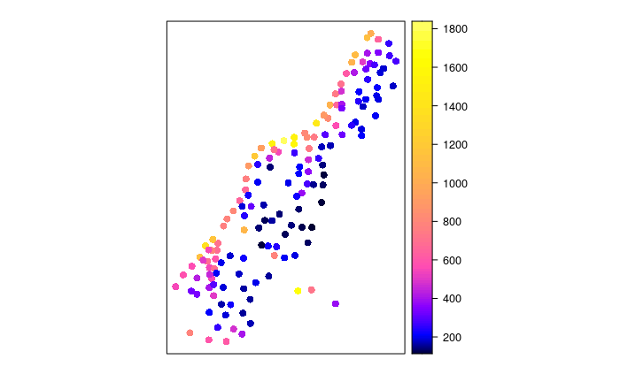

```r
coordinates(meuse) <- c("x", "y")
# EDA
spplot(meuse, "zinc", do.log = T, colorkey = TRUE)
```

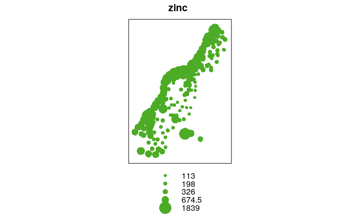

```r
bubble(meuse, "zinc", do.log = T, key.space = "bottom")
```

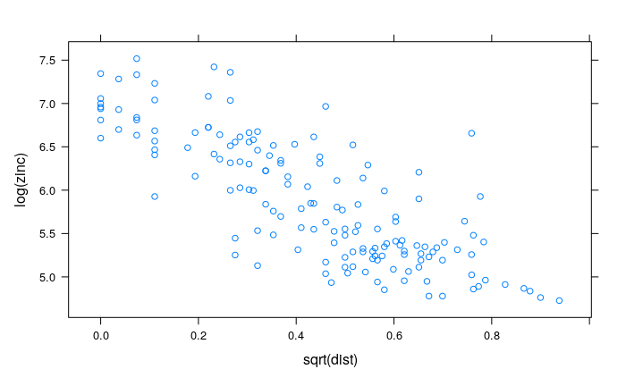

```r
# fitting
xyplot(log(zinc) ~ sqrt(dist), as.data.frame(meuse))
```

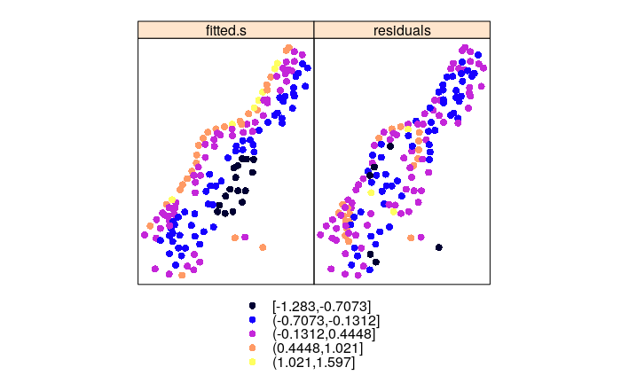

```r
zn.lm <- lm(log(zinc) ~ sqrt(dist), meuse)
meuse$fitted.s <- predict(zn.lm, meuse) - mean(predict(zn.lm,
meuse))
meuse$residuals <- residuals(zn.lm)
spplot(meuse, c("fitted.s", "residuals"))
```

Interpolacion por IDW

```r
data(meuse.grid)
class(meuse.grid)
```

```
[1] "data.frame"
```

```r
coordinates(meuse.grid) <- c("x", "y")
meuse.grid <- as(meuse.grid, "SpatialPixelsDataFrame")
idw.out <- gstat::idw(zinc ~ 1, meuse, meuse.grid, idp = 0.5)
```

```
[inverse distance weighted interpolation]
```

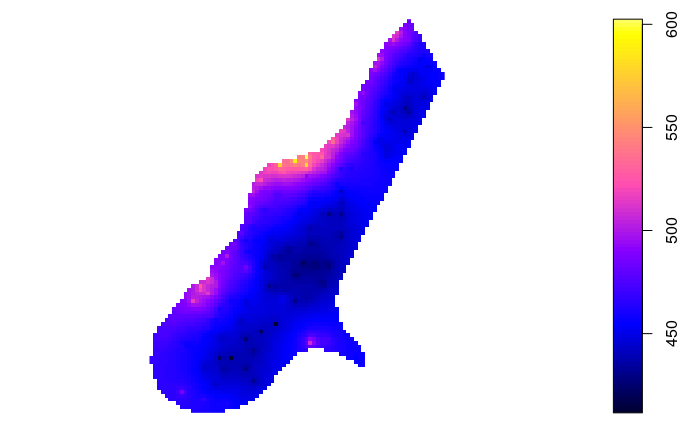

```r
plot(idw.out)
```

Interpolacion con Modelado Lineal

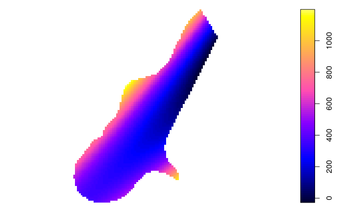

```r
#zn.lm <- lm(log(zinc) ~ sqrt(dist), meuse)
#zn.lm <- lm(zinc ~ sqrt(dist), meuse)
zn.lm <- lm(zinc ~ poly(x, y, degree = 2), meuse)
meuse.grid$pred <- predict(zn.lm, meuse.grid)
meuse.grid$se.fit <- predict(zn.lm, meuse.grid, se.fit = TRUE)$se.fit
plot(meuse.grid["pred"])
```

```r
#image(meuse.grid["pred"])
```

El Variograma de zinc

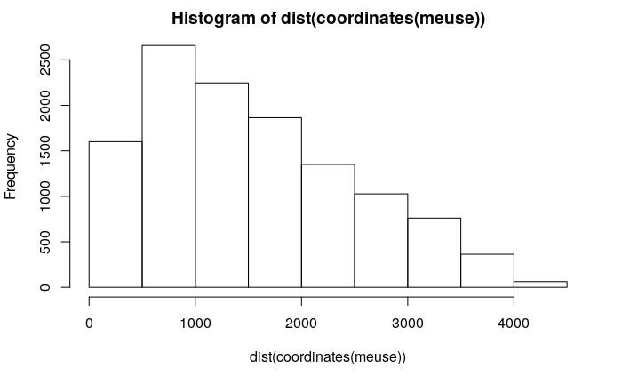

```r
hist(dist(coordinates(meuse)))
```

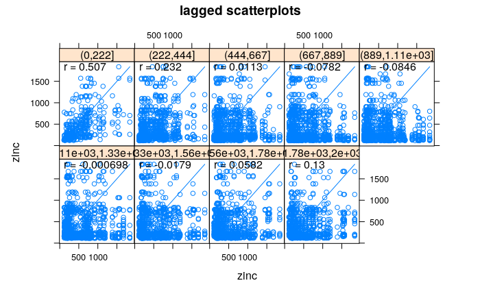

```r
hscat(zinc ~ 1, meuse, seq(0,2000,length.out = 10))
```

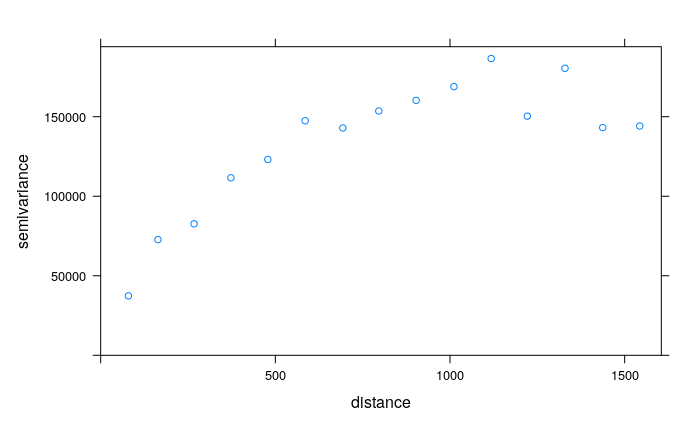

```r
#
sel <- plot(variogram(zinc ~ 1, meuse, cloud = FALSE))
sel
```

El Variograma de residuos

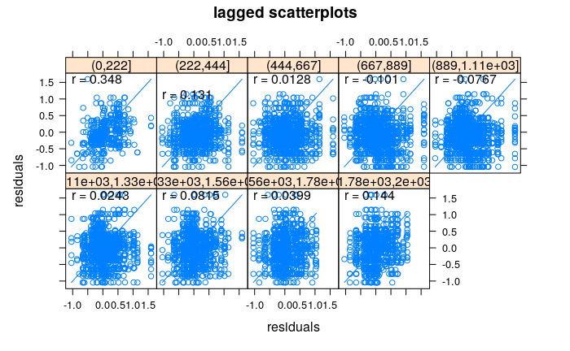

```r
hscat(residuals ~ 1, meuse, seq(0,2000,length.out = 10))
```

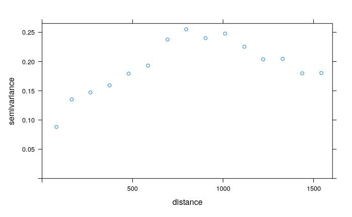

```r
#
sel <- plot(variogram(residuals ~ 1, meuse, cloud = FALSE))
sel
```

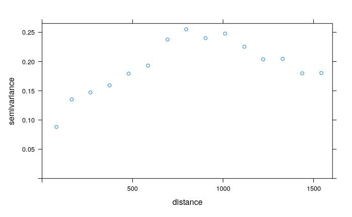

```r
#
sel2<-variogram(log(zinc) ~ sqrt(dist), meuse)
plot(sel2)
```

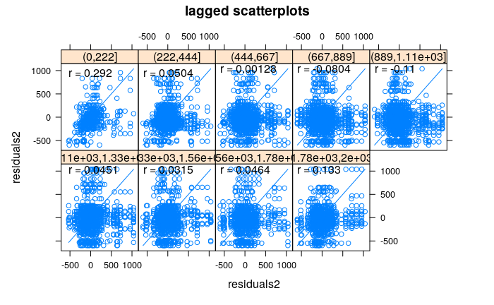

```r
#
zn.lm2 <- lm(zinc ~ dist+poly(x, y, degree = 2), meuse)
meuse$fitted2 <- predict(zn.lm2, meuse) - mean(predict(zn.lm2,
meuse))
meuse$residuals2 <- residuals(zn.lm2)
hscat(residuals2 ~ 1, meuse, seq(0,2000,length.out = 10))
```

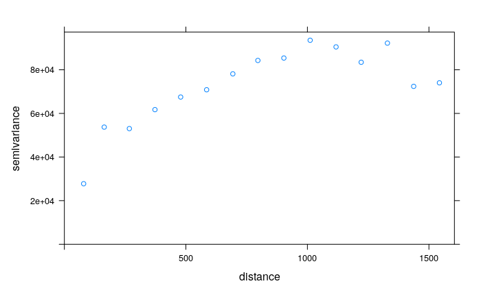

```r
#
sel <- plot(variogram(residuals2 ~ 1, meuse, cloud = FALSE))
sel
```

Procesos Marcados

SIN Autocorrelacion

```r
require(gstat)
#
set.seed(1)
sim.CSR.M<-sim.CSR
X<-rnorm(sim.CSR.M$n)
X<-as.numeric(scale(X))
marks(sim.CSR.M)<-X
sim.CSR.M
```

```
Marked planar point pattern: 91 points
marks are numeric, of storage type  ‘double’
window: rectangle = [0, 1] x [0, 1] units
```

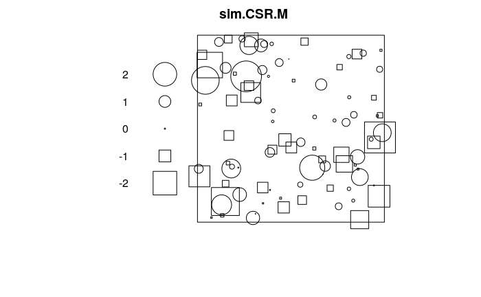

```r
sim.CSR.M.df<-as.data.frame(sim.CSR.M)
sim.CSR.M.spdf<-sim.CSR.M.df
coordinates(sim.CSR.M.spdf) <- c("x", "y") # como spatialpoints dataframe

plot(sim.CSR.M)
```

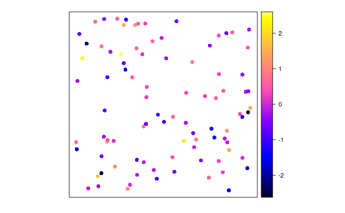

```r
spplot(sim.CSR.M.spdf, colorkey = TRUE)
```

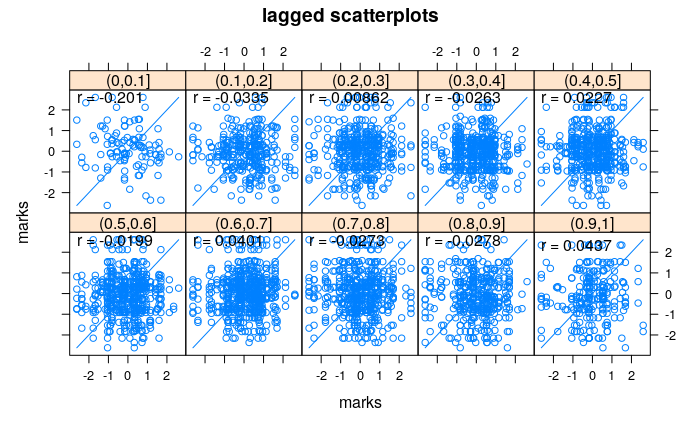

```r
### Vaiograma
hscat(marks ~ 1, sim.CSR.M.spdf, seq(0,1,length.out = 11))
```

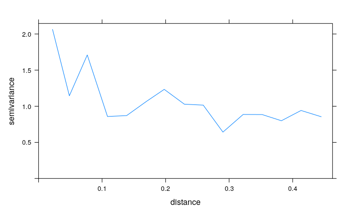

```r
variog<-variogram(marks ~ 1, sim.CSR.M.spdf)
plot(variog,type="l")
```

CON Autocorrelacion

A proṕosito NO uso ni gstat ni fields

Genero valores al azar y luego hago muchas pasadas (pp) en las que elijo un punto al azar y modifico su marca sumandole una fracción (ff) de los valores de los (Kk) puntos cercanos

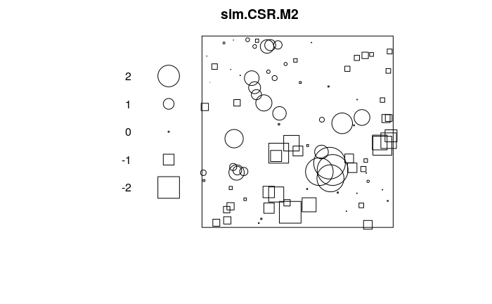

```r
require(nabor) # Libreria para calcular vecinos mas cercanos
sim.CSR.M2<-sim.CSR.M
n<-sim.CSR.M2$n
pp<-500
ff<-0.5
kk<-3
#
coordenadas<-coords(sim.CSR.M2)
vecinos<-knn(coordenadas,coordenadas,k=kk+1)$nn.idx[,2:(kk+1)] # busca vecinos
X.sac<-marks(sim.CSR.M2)
for (i in 1:pp)
{
  cual<-sample(1:n,1)
  X.sac[cual]<-X.sac[cual]+ff*mean(X.sac[vecinos[cual,]])
}
X.sac<-as.numeric(scale(X.sac))
marks(sim.CSR.M2)<-X.sac
sim.CSR.M2.df<-as.data.frame(sim.CSR.M2)
sim.CSR.M2.spdf<-sim.CSR.M2.df
coordinates(sim.CSR.M2.spdf) <- c("x", "y") # como spatialpoints dataframe

plot(sim.CSR.M2)
```

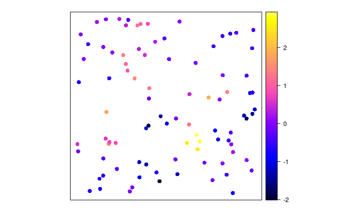

```r
spplot(sim.CSR.M2.spdf, colorkey = TRUE)
```

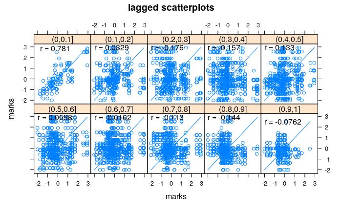

```r
### Vaiograma
hscat(marks ~ 1, sim.CSR.M2.spdf, seq(0,1,length.out = 11))
```

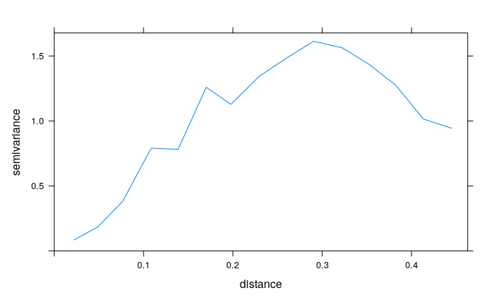

```r
variog<-variogram(marks ~ 1, sim.CSR.M2.spdf)
plot(variog,type="l")
```

Indice de Moran

```r
require(ape)
#
datos<-sim.CSR.M
datos.dists <- as.matrix(dist(cbind(sim.CSR.M$x, sim.CSR.M$y)))
datos.dists.inv <- 1/datos.dists
diag(datos.dists.inv) <- 0
Moran.I(marks(datos),datos.dists.inv)
```

```
$observed
[1] -0.04942335

$expected
[1] -0.01111111

$sd
[1] 0.01848804

$p.value
[1] 0.03824008
```

```r
#
datos<-sim.CSR.M2
datos.dists <- as.matrix(dist(cbind(sim.CSR.M$x, sim.CSR.M$y)))
datos.dists.inv <- 1/datos.dists
diag(datos.dists.inv) <- 0
Moran.I(marks(datos),datos.dists.inv)
```

```
$observed
[1] 0.1257112

$expected
[1] -0.01111111

$sd
[1] 0.01842769

$p.value
[1] 1.130207e-13
```

Kriging

```r
require(gstst)
data(meuse.grid)
class(meuse)
```

```
[1] "SpatialPointsDataFrame"
attr(,"package")
[1] "sp"
```

```r
class(meuse.grid)
```

```
[1] "data.frame"
```

```r
coordinates(meuse.grid) <- c("x", "y")

kri.meuse<- krige(zinc~1, meuse, meuse.grid)
```

```
[inverse distance weighted interpolation]
```

```r
class(meuse.grid)
```

```
[1] "SpatialPointsDataFrame"
attr(,"package")
[1] "sp"
```

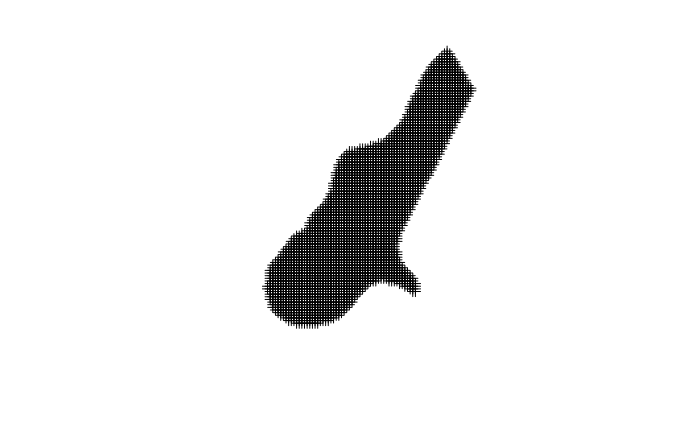

```r
plot(kri.meuse)
```

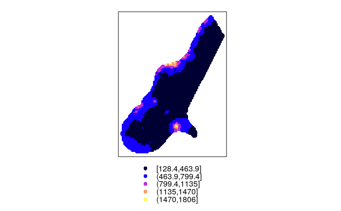

```r
spplot(kri.meuse["var1.pred"])
```

```r
#
M2.grid<-expand.grid(x=seq(0,1,length.out = 100),y=seq(0,1,length.out = 100))
coordinates(M2.grid) <- c("x", "y")
class(M2.grid)
```

```
[1] "SpatialPoints"
attr(,"package")
[1] "sp"
```

```r
m <- vgm(.59, "Sph", 874, .04)
kri.M2 <- krige(marks ~ 1, sim.CSR.M2.spdf,M2.grid,model=m)
```

```
[using ordinary kriging]
```

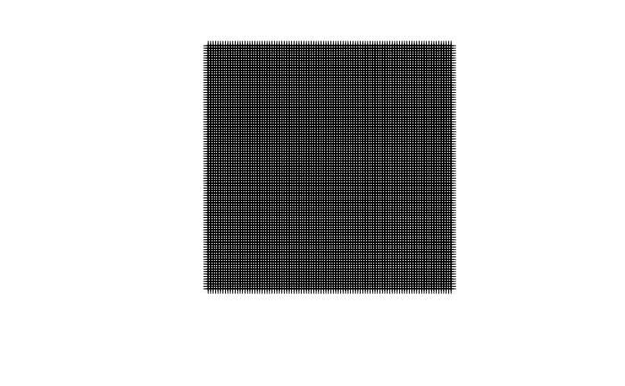

```r
plot(kri.M2)
```

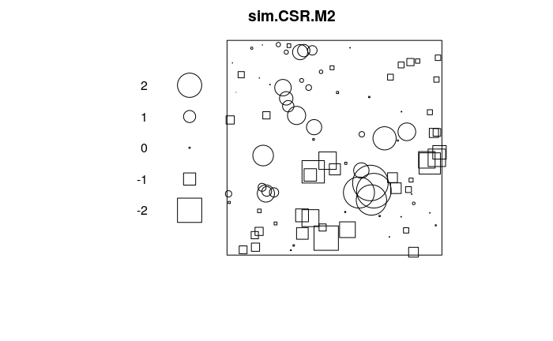

```r
plot(sim.CSR.M2)
```

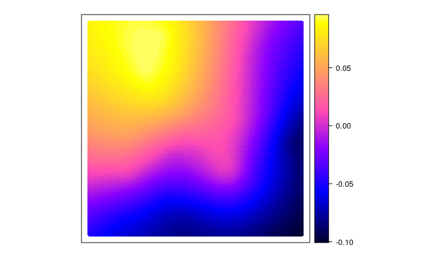

```r
spplot(kri.M2["var1.pred"], colorkey = TRUE)
```